# Análise de Dados - Aula 1

Ítalo e José Antonio

2024-10-06

##### Análise de Dados - Aula 1

### Questão 1

**Descrição:**  
O domínio do problema na base de dados “Predict student performance in secondary education” é a análise de desempenho escolar de estudantes de duas escolas portuguesas. O tipo de conhecimento que se espera encontrar envolve identificar fatores demográficos, sociais e escolares que influenciam o desempenho acadêmico dos alunos, tanto em matemática quanto em português. Padrões de correlação entre notas (G1, G2 e G3), variáveis socioeconômicas e comportamentais podem ser explorados para prever o sucesso ou dificuldades dos estudantes ao longo do ano.

Durante a junção das duas bases de dados, algumas variáveis podem aparecer com sufixos .x e .y, o que indica que a variável original estava presente em ambos os dataframes. O sufixo .x refere-se às variáveis do dataframe de Matemática, enquanto o sufixo .y corresponde às variáveis do dataframe de Português.

Por exemplo, as colunas G3.x e G3.y representam as notas finais dos alunos em Matemática e Português, respectivamente. Essa nomenclatura permite manter a clareza e a integridade dos dados, possibilitando análises separadas e comparações entre o desempenho dos estudantes nas duas disciplinas.

```r
d1=read.table("C:/Users/josej/OneDrive/Documentos/GitHub/EstudoDirigindo-MinecaoDeDados/OtherBase/student+performance/student-mat.csv",sep=";",header=TRUE)
d2=read.table("C:/Users/josej/OneDrive/Documentos/GitHub/EstudoDirigindo-MinecaoDeDados/OtherBase/student+performance/student-por.csv",sep=";",header=TRUE)

student_performance = merge(d1,d2,by=c("school","sex","age","address","famsize","Pstatus","Medu","Fedu","Mjob","Fjob","reason","nursery","internet"))
print(nrow(student_performance)) # 382 students
```

```
## [1] 382
```

```r
View(student_performance)
```

### Questão 2

**Descrição:**  
Aqui, ao utilizar as funções dim(), nrow() e ncol(), encontramos 382 amostras e 53 variáveis. Apesar da base de dados ter muitas variáveis, grande parte delas são do tipo True ou False, mesmo que não estejam formatadas como binárias ou booleanas. Achei a base interessante, com potencial para diversas análises diferentes.

```r
print(paste('Número de linhas(amostras):', nrow(student_performance)))
```

```
## [1] "Número de linhas(amostras): 382"
```

```r
print(paste('Número de colunas(variaveis):', ncol(student_performance)))
```

```
## [1] "Número de colunas(variaveis): 53"
```

### Questão 3

**Descrição:**  
Utilizamos a função `str()` para exibir a estrutura do conjunto de dados.

```r
# Exibir a estrutura do dataset
str(student_performance)
```

```
## 'data.frame':    382 obs. of  53 variables:
##  $ school      : chr  "GP" "GP" "GP" "GP" ...
##  $ sex         : chr  "F" "F" "F" "F" ...
##  $ age         : int  15 15 15 15 15 15 15 15 15 15 ...
##  $ address     : chr  "R" "R" "R" "R" ...
##  $ famsize     : chr  "GT3" "GT3" "GT3" "GT3" ...
##  $ Pstatus     : chr  "T" "T" "T" "T" ...
##  $ Medu        : int  1 1 2 2 3 3 3 2 3 3 ...
##  $ Fedu        : int  1 1 2 4 3 4 4 2 1 3 ...
##  $ Mjob        : chr  "at_home" "other" "at_home" "services" ...
##  $ Fjob        : chr  "other" "other" "other" "health" ...
##  $ reason      : chr  "home" "reputation" "reputation" "course" ...
##  $ nursery     : chr  "yes" "no" "yes" "yes" ...
##  $ internet    : chr  "yes" "yes" "no" "yes" ...
##  $ guardian.x  : chr  "mother" "mother" "mother" "mother" ...
```

[output cut: 39 more lines]

Nesse caso, as variáveis categóricas como school, sex, address, famsize, e outras variáveis com valores de “sim” e “não” precisam ser convertidas para factor, enquanto variáveis numéricas como age, Medu, Fedu, e as notas (G1, G2, G3) estão corretas como inteiros.

```r
student_performance$school <- as.factor(student_performance$school)
student_performance$sex <- as.factor(student_performance$sex)
student_performance$address <- as.factor(student_performance$address)
student_performance$famsize <- as.factor(student_performance$famsize)
student_performance$Pstatus <- as.factor(student_performance$Pstatus)
student_performance$Mjob <- as.factor(student_performance$Mjob)
student_performance$Fjob <- as.factor(student_performance$Fjob)
student_performance$reason <- as.factor(student_performance$reason)
student_performance$nursery <- as.factor(student_performance$nursery)
student_performance$internet <- as.factor(student_performance$internet)
student_performance$guardian.x <- as.factor(student_performance$guardian.x)
student_performance$schoolsup.x <- as.factor(student_performance$schoolsup.x)
student_performance$famsup.x <- as.factor(student_performance$famsup.x)
student_performance$paid.x <- as.factor(student_performance$paid.x)
student_performance$activities.x <- as.factor(student_performance$activities.x)
student_performance$higher.x <- as.factor(student_performance$higher.x)
student_performance$romantic.x <- as.factor(student_performance$romantic.x)

str(student_performance)
```

```
## 'data.frame':    382 obs. of  53 variables:
##  $ school      : Factor w/ 2 levels "GP","MS": 1 1 1 1 1 1 1 1 1 1 ...
##  $ sex         : Factor w/ 2 levels "F","M": 1 1 1 1 1 1 1 1 1 1 ...
##  $ age         : int  15 15 15 15 15 15 15 15 15 15 ...
##  $ address     : Factor w/ 2 levels "R","U": 1 1 1 1 1 1 1 1 1 2 ...
##  $ famsize     : Factor w/ 2 levels "GT3","LE3": 1 1 1 1 1 1 1 2 2 1 ...
##  $ Pstatus     : Factor w/ 2 levels "A","T": 2 2 2 2 2 2 2 2 2 1 ...
##  $ Medu        : int  1 1 2 2 3 3 3 2 3 3 ...
##  $ Fedu        : int  1 1 2 4 3 4 4 2 1 3 ...
##  $ Mjob        : Factor w/ 5 levels "at_home","health",..: 1 3 1 4 4 4 4 2 3 3 ...
##  $ Fjob        : Factor w/ 5 levels "at_home","health",..: 3 3 3 2 4 2 5 4 3 2 ...
##  $ reason      : Factor w/ 4 levels "course","home",..: 2 4 4 1 4 1 1 4 4 4 ...
##  $ nursery     : Factor w/ 2 levels "no","yes": 2 1 2 2 2 2 2 2 1 2 ...
##  $ internet    : Factor w/ 2 levels "no","yes": 2 2 1 2 2 2 2 2 2 1 ...
##  $ guardian.x  : Factor w/ 3 levels "father","mother",..: 2 2 2 2 3 2 1 2 1 1 ...
```

[output cut: 39 more lines]

### Questão 4

**Descrição:**  
Usado a função `summary()` temos resumo estatístico do dataframe, mas para garantir que nao exista valore NA, uma funcao de soma(sum) que vai contar a quantidade de valores NA no dataframe.

```r
# Resumo do dataset
summary(student_performance)
```

```
##  school   sex          age        address famsize   Pstatus      Medu
##  GP:342   F:198   Min.   :15.00   R: 81   GT3:278   A: 38   Min.   :0.000
##  MS: 40   M:184   1st Qu.:16.00   U:301   LE3:104   T:344   1st Qu.:2.000
##                   Median :17.00                             Median :3.000
##                   Mean   :16.59                             Mean   :2.806
##                   3rd Qu.:17.00                             3rd Qu.:4.000
##                   Max.   :22.00                             Max.   :4.000
##       Fedu             Mjob           Fjob            reason    nursery
##  Min.   :0.000   at_home : 53   at_home : 16   course    :140   no : 72
##  1st Qu.:2.000   health  : 33   health  : 17   home      :110   yes:310
##  Median :3.000   other   :138   other   :211   other     : 34
##  Mean   :2.565   services: 96   services:107   reputation: 98
##  3rd Qu.:4.000   teacher : 62   teacher : 31
##  Max.   :4.000
##  internet   guardian.x   traveltime.x    studytime.x      failures.x
##  no : 58   father: 91   Min.   :1.000   Min.   :1.000   Min.   :0.0000
##  yes:324   mother:275   1st Qu.:1.000   1st Qu.:1.000   1st Qu.:0.0000
##            other : 16   Median :1.000   Median :2.000   Median :0.0000
##                         Mean   :1.442   Mean   :2.034   Mean   :0.2906
##                         3rd Qu.:2.000   3rd Qu.:2.000   3rd Qu.:0.0000
##                         Max.   :4.000   Max.   :4.000   Max.   :3.0000
##  schoolsup.x famsup.x  paid.x    activities.x higher.x  romantic.x
##  no :331     no :144   no :205   no :181      no : 18   no :261
##  yes: 51     yes:238   yes:177   yes:201      yes:364   yes:121
##
##
##
##
##     famrel.x      freetime.x       goout.x          Dalc.x          Walc.x
##  Min.   :1.00   Min.   :1.000   Min.   :1.000   Min.   :1.000   Min.   :1.00
##  1st Qu.:4.00   1st Qu.:3.000   1st Qu.:2.000   1st Qu.:1.000   1st Qu.:1.00
##  Median :4.00   Median :3.000   Median :3.000   Median :1.000   Median :2.00
##  Mean   :3.94   Mean   :3.223   Mean   :3.113   Mean   :1.474   Mean   :2.28
##  3rd Qu.:5.00   3rd Qu.:4.000   3rd Qu.:4.000   3rd Qu.:2.000   3rd Qu.:3.00
##  Max.   :5.00   Max.   :5.000   Max.   :5.000   Max.   :5.000   Max.   :5.00
##     health.x       absences.x          G1.x            G2.x
##  Min.   :1.000   Min.   : 0.000   Min.   : 3.00   Min.   : 0.00
##  1st Qu.:3.000   1st Qu.: 0.000   1st Qu.: 8.00   1st Qu.: 8.25
##  Median :4.000   Median : 3.000   Median :10.50   Median :11.00
##  Mean   :3.579   Mean   : 5.319   Mean   :10.86   Mean   :10.71
```

[output cut: 22 more lines]

```
##                                                           Max.   :5.000
##    freetime.y      goout.y          Dalc.y          Walc.y         health.y
##  Min.   :1.00   Min.   :1.000   Min.   :1.000   Min.   :1.000   Min.   :1.000
##  1st Qu.:3.00   1st Qu.:2.000   1st Qu.:1.000   1st Qu.:1.000   1st Qu.:3.000
##  Median :3.00   Median :3.000   Median :1.000   Median :2.000   Median :4.000
##  Mean   :3.23   Mean   :3.118   Mean   :1.476   Mean   :2.291   Mean   :3.576
##  3rd Qu.:4.00   3rd Qu.:4.000   3rd Qu.:2.000   3rd Qu.:3.000   3rd Qu.:5.000
##  Max.   :5.00   Max.   :5.000   Max.   :5.000   Max.   :5.000   Max.   :5.000
##    absences.y          G1.y            G2.y            G3.y
##  Min.   : 0.000   Min.   : 0.00   Min.   : 5.00   Min.   : 0.00
##  1st Qu.: 0.000   1st Qu.:10.00   1st Qu.:11.00   1st Qu.:11.00
##  Median : 2.000   Median :12.00   Median :12.00   Median :13.00
##  Mean   : 3.673   Mean   :12.11   Mean   :12.24   Mean   :12.52
##  3rd Qu.: 6.000   3rd Qu.:14.00   3rd Qu.:14.00   3rd Qu.:14.00
##  Max.   :32.000   Max.   :19.00   Max.   :19.00   Max.   :19.00
```

```r
# Contar o número total de NAs
quant_na <- sum(is.na(student_performance))

# Exibir o total de NAs
print(paste("Quantidade de dados ausentes(NA):", quant_na))
```

```
## [1] "Quantidade de dados ausentes(NA): 0"
```

### Questão 5

```r
# Contar amostras em cada classe das variáveis G3.x e G3.y
count_G3_x <- table(student_performance$G3.x)
count_G3_y <- table(student_performance$G3.y)

# Criar data frames organizados com os nomes de coluna corretos
df_porcentagem_G3_x <- as.data.frame(count_G3_x)
colnames(df_porcentagem_G3_x) <- c("Classe", "Amostra")

# Calcular a porcentagem e adicionar como nova coluna
df_porcentagem_G3_x <- df_porcentagem_G3_x %>%
  mutate(Porcentagem = round((Amostra / sum(Amostra)) * 100, 2))

df_porcentagem_G3_y <- as.data.frame(count_G3_y)
colnames(df_porcentagem_G3_y) <- c("Classe", "Amostra")

# Calcular a porcentagem e adicionar como nova coluna
df_porcentagem_G3_y <- df_porcentagem_G3_y %>%
  mutate(Porcentagem = round((Amostra / sum(Amostra)) * 100, 2))

# Ordenar os data frames pela porcentagem em ordem decrescente
df_porcentagem_G3_x <- df_porcentagem_G3_x %>% arrange(desc(Porcentagem))
df_porcentagem_G3_y <- df_porcentagem_G3_y %>% arrange(desc(Porcentagem))

# Formatar a coluna de porcentagem
df_porcentagem_G3_x$Porcentagem <- percent(df_porcentagem_G3_x$Porcentagem / 100)
df_porcentagem_G3_y$Porcentagem <- percent(df_porcentagem_G3_y$Porcentagem / 100)

# Exibir as tabelas com kable
kable(df_porcentagem_G3_x, caption = "Porcentagem da Classe: G3.x")
```

Porcentagem da Classe: G3.x

| Classe | Amostra | Porcentagem |
| --- | --- | --- |
| 10 | 56 | 14.66% |
| 11 | 43 | 11.26% |
| 0 | 39 | 10.21% |
| 15 | 32 | 8.38% |
| 8 | 31 | 8.12% |
| 12 | 30 | 7.85% |
| 9 | 27 | 7.07% |
| 14 | 27 | 7.07% |
| 13 | 25 | 6.54% |
| 16 | 17 | 4.45% |
| 6 | 15 | 3.93% |
| 18 | 13 | 3.40% |
| 5 | 7 | 1.83% |
| 7 | 7 | 1.83% |
| 17 | 6 | 1.57% |
| 19 | 5 | 1.31% |
| 4 | 1 | 0.26% |
| 20 | 1 | 0.26% |

```r
kable(df_porcentagem_G3_y, caption = "Porcentagem da Classe: G3.y")
```

Porcentagem da Classe: G3.y

| Classe | Amostra | Porcentagem |
| --- | --- | --- |
| 13 | 63 | 16.49% |
| 12 | 55 | 14.40% |
| 11 | 54 | 14.14% |
| 10 | 46 | 12.04% |
| 14 | 41 | 10.73% |
| 15 | 33 | 8.64% |
| 16 | 28 | 7.33% |
| 17 | 19 | 4.97% |
| 9 | 11 | 2.88% |
| 18 | 9 | 2.36% |
| 8 | 8 | 2.09% |
| 0 | 5 | 1.31% |
| 6 | 3 | 0.79% |
| 7 | 3 | 0.79% |
| 19 | 2 | 0.52% |
| 1 | 1 | 0.26% |
| 5 | 1 | 0.26% |

### Questão 6

```r
# Contar amostras em cada classe para G3.x e G3.y
count_G3_x <- table(student_performance$G3.x)
count_G3_y <- table(student_performance$G3.y)

# Criar data frames organizados
df_porcentagem_G3_x <- data.frame(
  Classe = names(count_G3_x),
  Amostra = as.vector(count_G3_x)
)

df_porcentagem_G3_y <- data.frame(
  Classe = names(count_G3_y),
  Amostra = as.vector(count_G3_y)
)

# Calcular porcentagens
df_porcentagem_G3_x$Porcentagem <- round((df_porcentagem_G3_x$Amostra / sum(df_porcentagem_G3_x$Amostra)) * 100, 2)
df_porcentagem_G3_y$Porcentagem <- round((df_porcentagem_G3_y$Amostra / sum(df_porcentagem_G3_y$Amostra)) * 100, 2)

# Ordenar os data frames pela porcentagem em ordem decrescente
df_porcentagem_G3_x <- df_porcentagem_G3_x %>% arrange(desc(Porcentagem))
df_porcentagem_G3_y <- df_porcentagem_G3_y %>% arrange(desc(Porcentagem))

# Visualizar resultados
print(df_porcentagem_G3_x)
```

```
##    Classe Amostra Porcentagem
## 1      10      56       14.66
## 2      11      43       11.26
## 3       0      39       10.21
## 4      15      32        8.38
## 5       8      31        8.12
## 6      12      30        7.85
## 7       9      27        7.07
## 8      14      27        7.07
## 9      13      25        6.54
## 10     16      17        4.45
## 11      6      15        3.93
## 12     18      13        3.40
## 13      5       7        1.83
## 14      7       7        1.83
## 15     17       6        1.57
## 16     19       5        1.31
## 17      4       1        0.26
## 18     20       1        0.26
```

```r
print(df_porcentagem_G3_y)
```

```
##    Classe Amostra Porcentagem
## 1      13      63       16.49
## 2      12      55       14.40
## 3      11      54       14.14
## 4      10      46       12.04
## 5      14      41       10.73
## 6      15      33        8.64
## 7      16      28        7.33
## 8      17      19        4.97
## 9       9      11        2.88
## 10     18       9        2.36
## 11      8       8        2.09
## 12      0       5        1.31
## 13      6       3        0.79
## 14      7       3        0.79
## 15     19       2        0.52
## 16      1       1        0.26
## 17      5       1        0.26
```

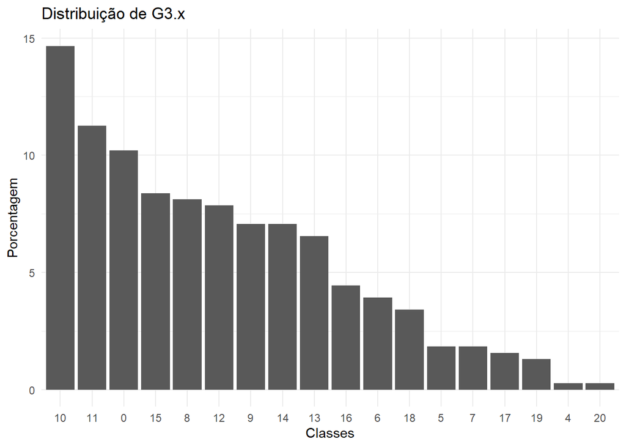

```r
# Criar gráficos de barras para visualizar a distribuição das classes
library(ggplot2)

# Ordenar a coluna Classe dinamicamente com os níveis únicos
df_porcentagem_G3_x$Classe <- factor(df_porcentagem_G3_x$Classe, levels = unique(df_porcentagem_G3_x$Classe))
df_porcentagem_G3_y$Classe <- factor(df_porcentagem_G3_y$Classe, levels = unique(df_porcentagem_G3_y$Classe))

# Gráfico para G3.x
ggplot(df_porcentagem_G3_x, aes(x = Classe, y = Porcentagem)) +
  geom_bar(stat = "identity") +
  labs(title = "Distribuição de G3.x", x = "Classes", y = "Porcentagem") +
  theme_minimal()
```

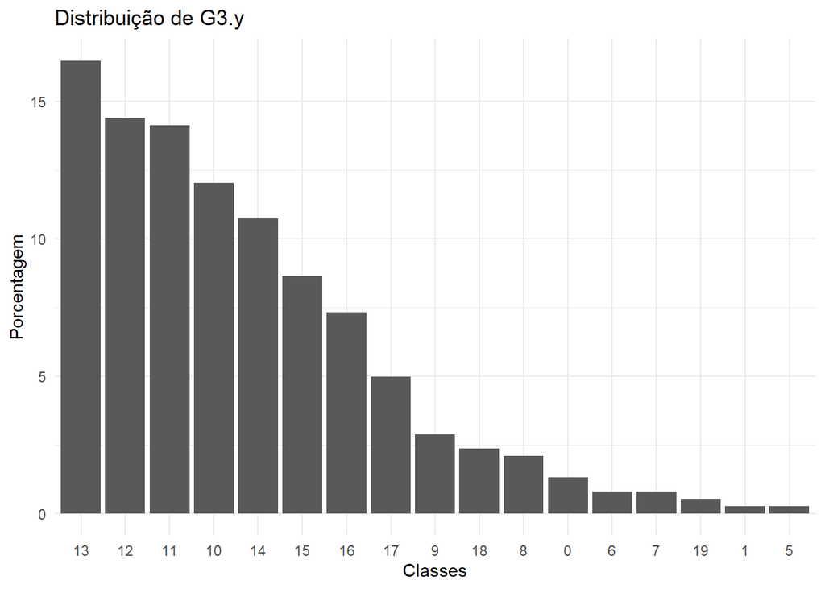

```r
# Gráfico para G3.y
ggplot(df_porcentagem_G3_y, aes(x = Classe, y = Porcentagem)) +
  geom_bar(stat = "identity") +
  labs(title = "Distribuição de G3.y", x = "Classes", y = "Porcentagem") +
  theme_minimal()
```

#### age_distribution

Vou fazer uma analises para verficar como está a balaceamento de numero de amostras de dados em relacao a idade, pois mais para frente tenho a inteção de fazer algumas analises pensado na idade.

```r
# Contar o número de amostras para cada idade
age_distribution <- table(student_performance$age)

# Criar um data frame organizado
df_age_distribution <- data.frame(
  Idade = names(age_distribution),
  Amostras = as.vector(age_distribution)
)

# Mostrar o resultado
print(df_age_distribution)
```

```
##   Idade Amostras
## 1    15       81
## 2    16      107
## 3    17      100
## 4    18       81
## 5    19       11
## 6    20        1
## 7    22        1
```

### Questão 7

**Descrição:**  
Para calcular a média e o desvio padrão vou usar as funções mean() e sd(). Vou demosntrar para apenas alguma variavel mais importantes/interessante na minha visão: Medu: Refere-se ao nível de educação da mãe, onde valores inteiros indicam anos de escolaridade.

Fedu: Assim como Medu, essa variável indica o nível de educação do pai, também expressa em anos de escolaridade.

studytime.x e studytime.y: Representam o tempo dedicado aos estudos. Um tempo maior de estudo pode estar relacionado a um melhor desempenho acadêmico.

G1, G2, G3: Essas variáveis indicam as notas dos alunos em diferentes períodos (G1 é a primeira nota, G2 a segunda, e G3 a nota final). São fundamentais para analisar o desempenho acadêmico.

Dalc.x e Dalc.y: Indicam o consumo de álcool durante a semana, que pode ter uma correlação com o desempenho escolar.

Walc.x e Walc.y: Representam o consumo de álcool nos fins de semana. Assim como Dalc, pode afetar o desempenho dos alunos.

#### Medu

```r
media_Medu <- mean(student_performance$Medu)

desvio_padrao_Medu <- sd(student_performance$Medu)

print(paste("Média dos valores esperados (Medu):", round(media_Medu, 2)))
```

```
## [1] "Média dos valores esperados (Medu): 2.81"
```

```r
print(paste("Desvio padrão dos valores esperados (Medu):", round(desvio_padrao_Medu, 2)))
```

```
## [1] "Desvio padrão dos valores esperados (Medu): 1.09"
```

#### Fedu

```r
media_Fedu <- mean(student_performance$Fedu)

desvio_padrao_Fedu <- sd(student_performance$Fedu)

print(paste("Média dos valores esperados (Fedu):", round(media_Fedu, 2)))
```

```
## [1] "Média dos valores esperados (Fedu): 2.57"
```

```r
print(paste("Desvio padrão dos valores esperados (Fedu):", round(desvio_padrao_Fedu, 2)))
```

```
## [1] "Desvio padrão dos valores esperados (Fedu): 1.1"
```

#### studytime.x e studytime.y

```r
# Média e desvio padrão para studytime.x
media_studytime_x <- mean(student_performance$studytime.x, na.rm = TRUE)
desvio_studytime_x <- sd(student_performance$studytime.x, na.rm = TRUE)

# Média e desvio padrão para studytime.y
media_studytime_y <- mean(student_performance$studytime.y, na.rm = TRUE)
desvio_studytime_y <- sd(student_performance$studytime.y, na.rm = TRUE)

# Resultados
cat("studytime.x - Média:", media_studytime_x, "Desvio Padrão:", desvio_studytime_x, "\n")
```

```
## studytime.x - Média: 2.034031 Desvio Padrão: 0.845798
```

```r
cat("studytime.y - Média:", media_studytime_y, "Desvio Padrão:", desvio_studytime_y, "\n")
```

```
## studytime.y - Média: 2.039267 Desvio Padrão: 0.8455705
```

#### Dalc.x e Dalc.y

```r
# Média e desvio padrão para Dalc.x
media_Dalc_x <- mean(student_performance$Dalc.x, na.rm = TRUE)
desvio_Dalc_x <- sd(student_performance$Dalc.x, na.rm = TRUE)

# Média e desvio padrão para Dalc.y
media_Dalc_y <- mean(student_performance$Dalc.y, na.rm = TRUE)
desvio_Dalc_y <- sd(student_performance$Dalc.y, na.rm = TRUE)

# Resultados Dalc
cat("Dalc.x - Média:", media_Dalc_x, "Desvio Padrão:", desvio_Dalc_x, "\n")
```

```
## Dalc.x - Média: 1.473822 Desvio Padrão: 0.8862292
```

```r
cat("Dalc.y - Média:", media_Dalc_y, "Desvio Padrão:", desvio_Dalc_y, "\n")
```

```
## Dalc.y - Média: 1.47644 Desvio Padrão: 0.8863028
```

#### G1, G2, G3

```r
# Média e desvio padrão para G1
media_G1 <- mean(student_performance$G1.x, na.rm = TRUE)
desvio_G1 <- sd(student_performance$G1.x, na.rm = TRUE)

# Média e desvio padrão para G2
media_G2 <- mean(student_performance$G2.x, na.rm = TRUE)
desvio_G2 <- sd(student_performance$G2.x, na.rm = TRUE)

# Média e desvio padrão para G3
media_G3 <- mean(student_performance$G3.x, na.rm = TRUE)
desvio_G3 <- sd(student_performance$G3.x, na.rm = TRUE)
```

#### Walc.x e Walc.y

```r
# Média e desvio padrão para Walc.x
media_Walc_x <- mean(student_performance$Walc.x, na.rm = TRUE)
desvio_Walc_x <- sd(student_performance$Walc.x, na.rm = TRUE)

# Média e desvio padrão para Walc.y
media_Walc_y <- mean(student_performance$Walc.y, na.rm = TRUE)
desvio_Walc_y <- sd(student_performance$Walc.y, na.rm = TRUE)

# Resultados Walc
cat("Walc.x - Média:", media_Walc_x, "Desvio Padrão:", desvio_Walc_x, "\n")
```

```
## Walc.x - Média: 2.280105 Desvio Padrão: 1.282866
```

```r
cat("Walc.y - Média:", media_Walc_y, "Desvio Padrão:", desvio_Walc_y, "\n")
```

```
## Walc.y - Média: 2.290576 Desvio Padrão: 1.282577
```

### Questão 8

**Descrição:**  
Para identificar outliers nas variáveis mais importantes, vou utilizar o gráfico boxplot.

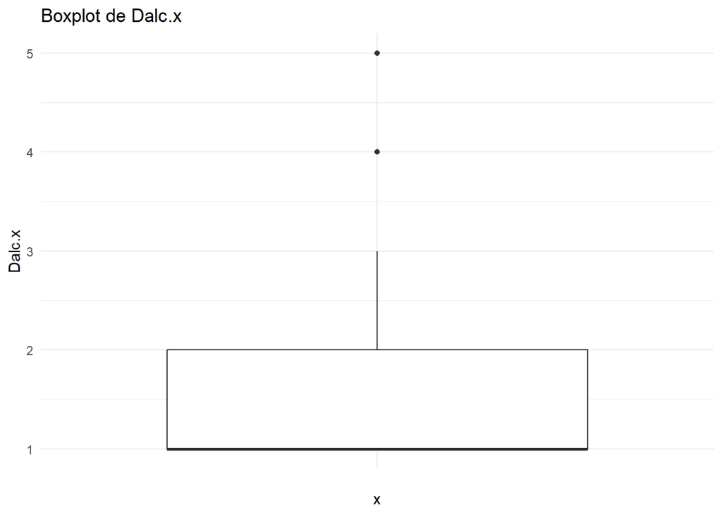

```r
# Carregar a biblioteca necessária
library(ggplot2)

# Boxplot para Dalc.x
ggplot(student_performance, aes(x = "", y = Dalc.x)) +
  geom_boxplot() +
  labs(title = "Boxplot de Dalc.x", y = "Dalc.x") +
  theme_minimal()
```

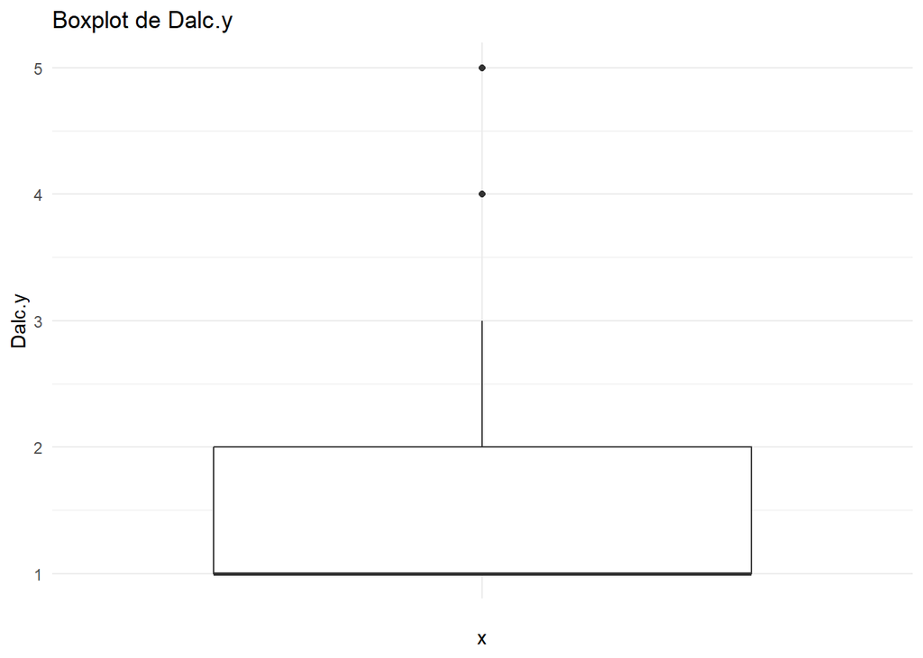

```r
# Boxplot para Dalc.y
ggplot(student_performance, aes(x = "", y = Dalc.y)) +
  geom_boxplot() +
  labs(title = "Boxplot de Dalc.y", y = "Dalc.y") +
  theme_minimal()
```

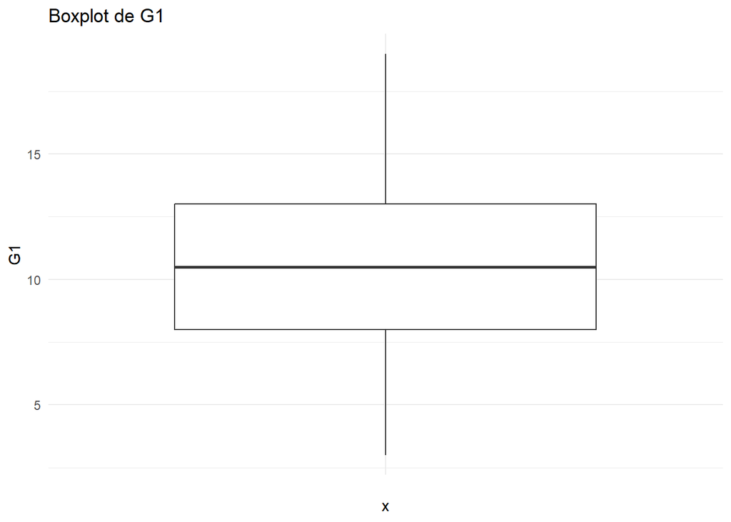

```r
# Boxplot para G1
ggplot(student_performance, aes(x = "", y = G1.x)) +
  geom_boxplot() +
  labs(title = "Boxplot de G1", y = "G1") +
  theme_minimal()
```

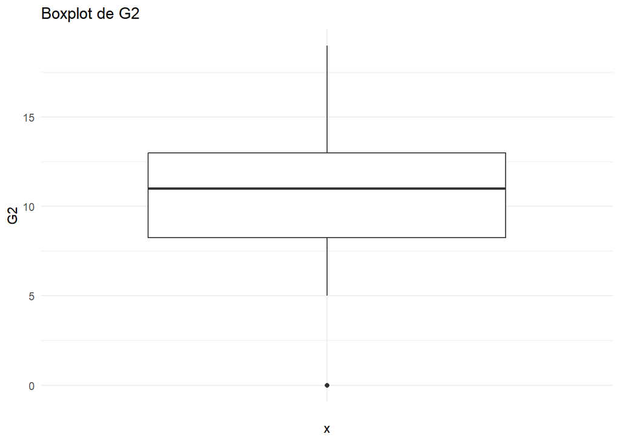

```r
# Boxplot para G2
ggplot(student_performance, aes(x = "", y = G2.x)) +
  geom_boxplot() +
  labs(title = "Boxplot de G2", y = "G2") +
  theme_minimal()
```

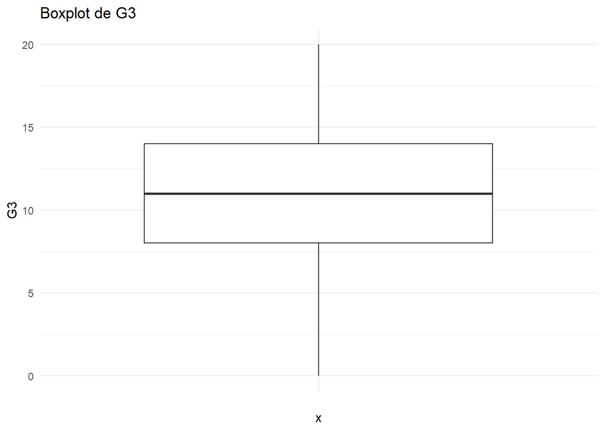

```r
# Boxplot para G3
ggplot(student_performance, aes(x = "", y = G3.x)) +
  geom_boxplot() +
  labs(title = "Boxplot de G3", y = "G3") +
  theme_minimal()
```

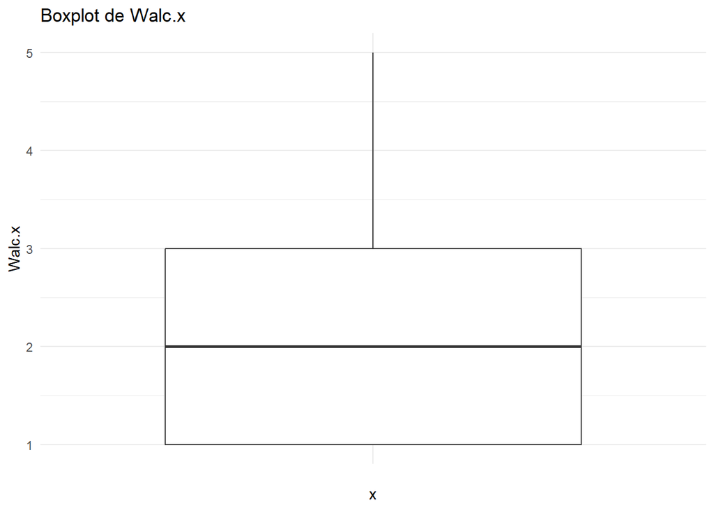

```r
# Boxplot para Walc.x
ggplot(student_performance, aes(x = "", y = Walc.x)) +
  geom_boxplot() +
  labs(title = "Boxplot de Walc.x", y = "Walc.x") +
  theme_minimal()
```

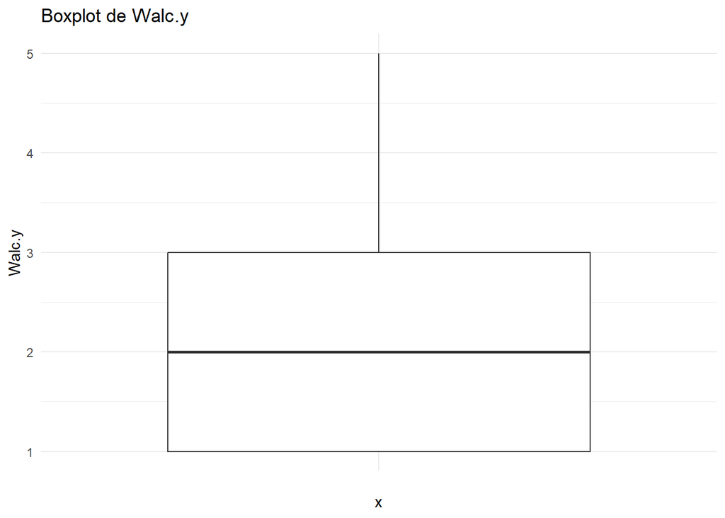

```r
# Boxplot para Walc.y
ggplot(student_performance, aes(x = "", y = Walc.y)) +
  geom_boxplot() +
  labs(title = "Boxplot de Walc.y", y = "Walc.y") +
  theme_minimal()
```

### Questão 9

**Descrição:**

```r
# Função para criar uma tabela de estatísticas descritivas
descriptive_stats <- function(variable) {
  return(data.frame(
    Minimo = min(variable, na.rm = TRUE),
    Maximo = max(variable, na.rm = TRUE),
    Media = mean(variable, na.rm = TRUE),
    Desvio_Padrao = sd(variable, na.rm = TRUE)
  ))
}

# Aplicar a função para cada variável
resultado_Dalc.x <- descriptive_stats(student_performance$Dalc.x)
resultado_Dalc.y <- descriptive_stats(student_performance$Dalc.y)
resultado_G1 <- descriptive_stats(student_performance$G1.y)
resultado_G2 <- descriptive_stats(student_performance$G2.y)
resultado_G3 <- descriptive_stats(student_performance$G3.y)
resultado_Walc.x <- descriptive_stats(student_performance$Walc.x)
resultado_Walc.y <- descriptive_stats(student_performance$Walc.y)

# Combinar resultados em uma tabela
tabela_resultados <- data.frame(
  Variavel = c("Dalc.x", "Dalc.y", "G1.y", "G2.y", "G3.y", "Walc.x", "Walc.y"),
  Minimo = c(resultado_Dalc.x$Minimo, resultado_Dalc.y$Minimo, resultado_G1$Minimo, resultado_G2$Minimo, resultado_G3$Minimo, resultado_Walc.x$Minimo, resultado_Walc.y$Minimo),
  Maximo = c(resultado_Dalc.x$Maximo, resultado_Dalc.y$Maximo, resultado_G1$Maximo, resultado_G2$Maximo, resultado_G3$Maximo, resultado_Walc.x$Maximo, resultado_Walc.y$Maximo),
  Media = c(resultado_Dalc.x$Media, resultado_Dalc.y$Media, resultado_G1$Media, resultado_G2$Media, resultado_G3$Media, resultado_Walc.x$Media, resultado_Walc.y$Media),
  Desvio_Padrao = c(resultado_Dalc.x$Desvio_Padrao, resultado_Dalc.y$Desvio_Padrao, resultado_G1$Desvio_Padrao, resultado_G2$Desvio_Padrao, resultado_G3$Desvio_Padrao, resultado_Walc.x$Desvio_Padrao, resultado_Walc.y$Desvio_Padrao)
)

print(tabela_resultados)
```

```
##   Variavel Minimo Maximo     Media Desvio_Padrao
## 1   Dalc.x      1      5  1.473822     0.8862292
## 2   Dalc.y      1      5  1.476440     0.8863028
## 3     G1.y      0     19 12.112565     2.5565313
## 4     G2.y      5     19 12.238220     2.4683413
## 5     G3.y      0     19 12.515707     2.9454381
## 6   Walc.x      1      5  2.280105     1.2828659
## 7   Walc.y      1      5  2.290576     1.2825766
```

### Questão 10

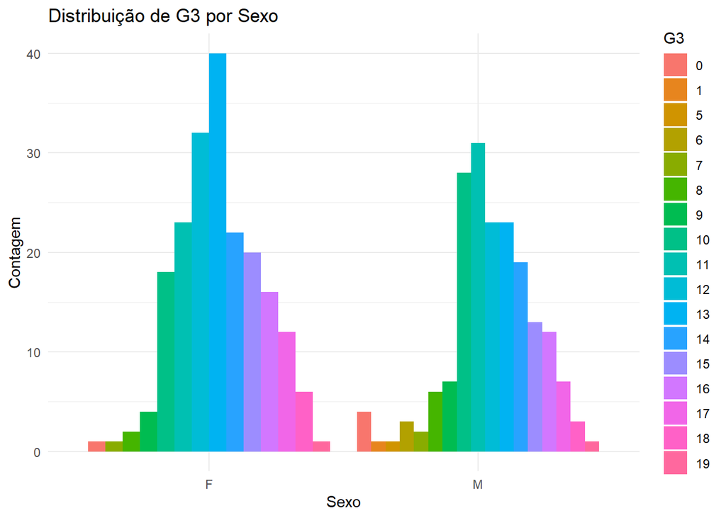

```r
library(ggplot2)
library(dplyr)

# Gráfico de barras para uma variável categórica (exemplo: sex)
ggplot(student_performance, aes(x = sex, fill = as.factor(G3.y))) +
  geom_bar(position = "dodge") +
  labs(title = "Distribuição de G3 por Sexo", x = "Sexo", y = "Contagem", fill = "G3") +
  theme_minimal()
```

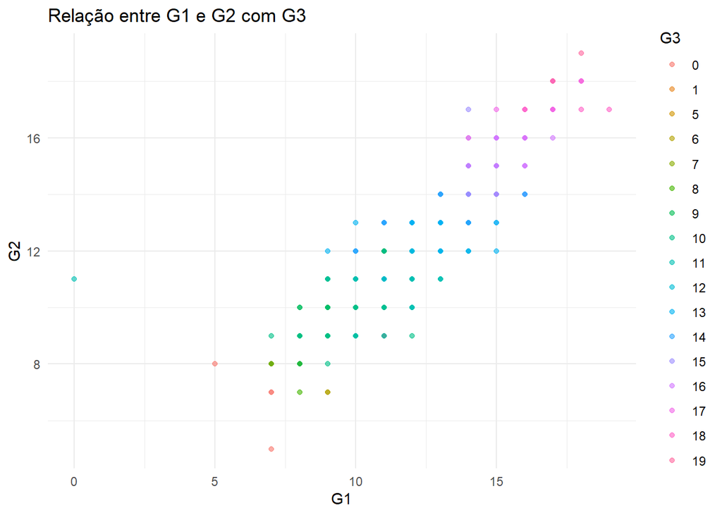

```r
# Gráfico de dispersão para uma variável numérica (exemplo: G1 vs G2)
ggplot(student_performance, aes(x = G1.y, y = G2.y, color = as.factor(G3.y))) +
  geom_point(alpha = 0.6) +
  labs(title = "Relação entre G1 e G2 com G3", x = "G1", y = "G2", color = "G3") +
  theme_minimal()
```

```r
  # Calcular o coeficiente de correlação
correlation <- cor(student_performance$age, student_performance$G3.y, use = "complete.obs")
print(paste("Coeficiente de correlação entre idade e G3:", correlation))
```

```
## [1] "Coeficiente de correlação entre idade e G3: -0.0679774770960381"
```

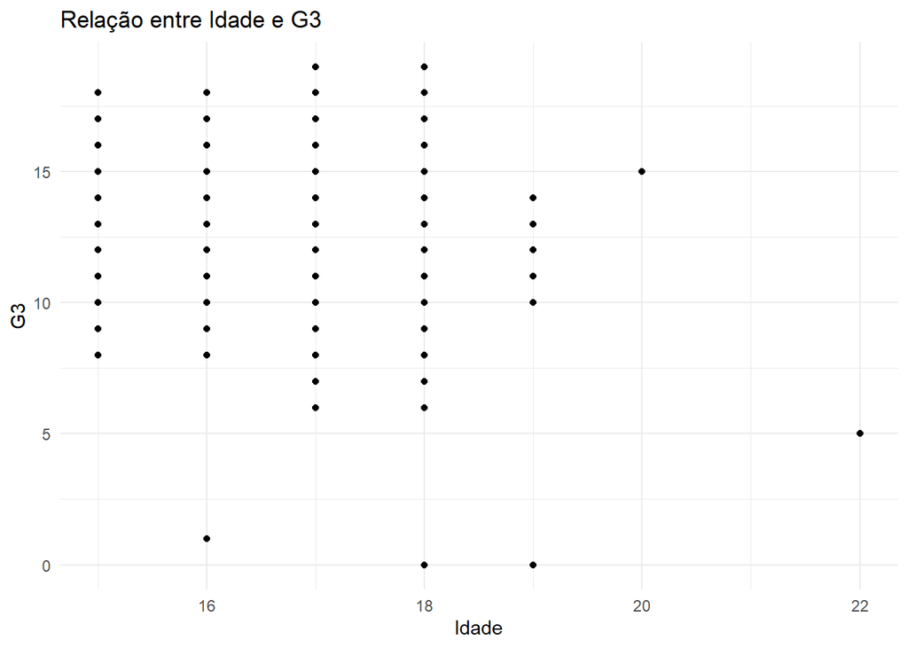

```r
# Gráfico de dispersão
ggplot(student_performance, aes(x = age, y = G3.y)) +
  geom_point() +
  labs(title = "Relação entre Idade e G3", x = "Idade", y = "G3") +
  theme_minimal()
```

Com base nas análises realizadas, foram identificados alguns pontos interessantes sobre o desempenho dos alunos nas notas finais (G3):

Desempenho do Sexo Feminino: A análise mostrou que as alunas do sexo feminino apresentam médias finais (G3) superiores em comparação aos alunos do sexo masculino. Essa diferença pode indicar não apenas uma maior dedicação, mas também a presença de fatores socioeconômicos ou culturais que influenciam o desempenho acadêmico entre os gêneros.

Consistência nas Notas: Observou-se que alunos que obtiveram uma boa nota na primeira avaliação (G1) tendem a manter essa média nas avaliações subsequentes (G2 e G3). Isso sugere que o desempenho inicial pode ser um bom indicador do sucesso contínuo, indicando a importância da motivação e da confiança no processo de aprendizagem.

### Questão 11

**Descrição:**  
Para ajudar a identificar quais variáveis têm maior influência na nota final G3, e assim facilitando a análise, vou separar em dois graficos, e vou pegar como foco a variavel G3, que seria a nota final

```r
# Calcular a correlação entre todas as variáveis numéricas e G3.x
correlations_x <- cor(student_performance[, sapply(student_performance, is.numeric)], use = "complete.obs")

# Selecionar as correlações com G3.x
cor_g3_x <- correlations_x[,"G3.x"]

# Exibir as correlações
print(cor_g3_x)
```

```
##          age         Medu         Fedu traveltime.x  studytime.x   failures.x
##  -0.19458854   0.20548938   0.15544405  -0.12600432   0.09133868  -0.38074148
##     famrel.x   freetime.x      goout.x       Dalc.x       Walc.x     health.x
##   0.06860282   0.01760404  -0.10965436  -0.04494050  -0.02726133  -0.05942978
##   absences.x         G1.x         G2.x         G3.x traveltime.y  studytime.y
##   0.02898725   0.80512870   0.90302671   1.00000000  -0.14881806   0.08555229
##   failures.y     famrel.y   freetime.y      goout.y       Dalc.y       Walc.y
##  -0.14829067   0.04529764  -0.01255909  -0.12270650  -0.03570463  -0.03973203
##     health.y   absences.y         G1.y         G2.y         G3.y
##  -0.05990827  -0.15803320   0.49530474   0.53555152   0.48034936
```

```r
# Ordenar as correlações em ordem decrescente
cor_g3_x_sorted <- sort(cor_g3_x, decreasing = TRUE)

print(cor_g3_x_sorted)
```

```
##         G3.x         G2.x         G1.x         G2.y         G1.y         G3.y
##   1.00000000   0.90302671   0.80512870   0.53555152   0.49530474   0.48034936
##         Medu         Fedu  studytime.x  studytime.y     famrel.x     famrel.y
##   0.20548938   0.15544405   0.09133868   0.08555229   0.06860282   0.04529764
##   absences.x   freetime.x   freetime.y       Walc.x       Dalc.y       Walc.y
##   0.02898725   0.01760404  -0.01255909  -0.02726133  -0.03570463  -0.03973203
##       Dalc.x     health.x     health.y      goout.x      goout.y traveltime.x
##  -0.04494050  -0.05942978  -0.05990827  -0.10965436  -0.12270650  -0.12600432
##   failures.y traveltime.y   absences.y          age   failures.x
##  -0.14829067  -0.14881806  -0.15803320  -0.19458854  -0.38074148
```

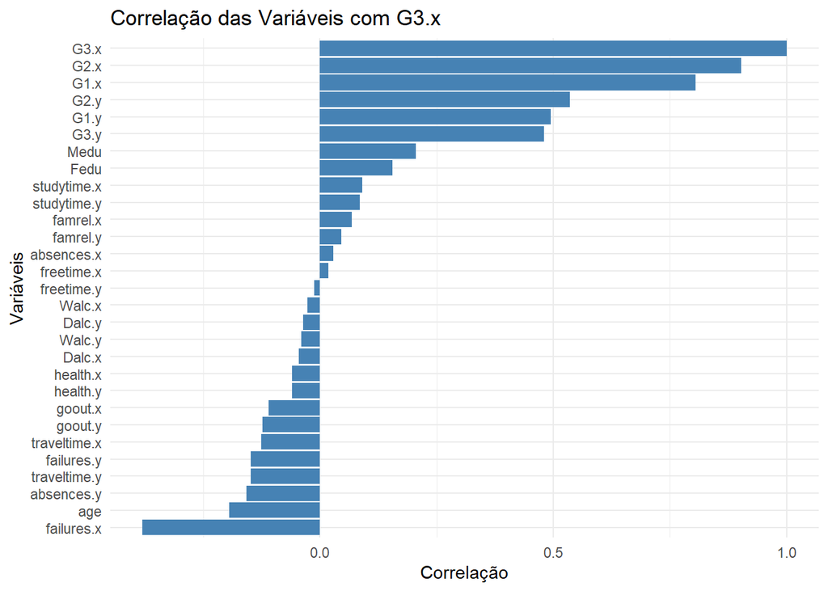

```r
library(ggplot2)
cor_g3_x_df <- as.data.frame(cor_g3_x_sorted)
cor_g3_x_df$Variable <- rownames(cor_g3_x_df)
colnames(cor_g3_x_df) <- c("Correlation", "Variable")

ggplot(cor_g3_x_df, aes(x = reorder(Variable, Correlation), y = Correlation)) +
  geom_bar(stat = "identity", fill = "steelblue") +
  coord_flip() +
  labs(title = "Correlação das Variáveis com G3.x",
       x = "Variáveis",
       y = "Correlação") +
  theme_minimal()
```

Agora vou fazer a correlação tambem para G3.y

```r
# Calcular a correlação entre todas as variáveis numéricas e G3.y
correlations_y <- cor(student_performance[, sapply(student_performance, is.numeric)], use = "complete.obs")

# Selecionar as correlações com G3.y
cor_g3_y <- correlations_y[,"G3.y"]

# Exibir as correlações
print(cor_g3_y)
```

```
##          age         Medu         Fedu traveltime.x  studytime.x   failures.x
##  -0.06797748   0.20355366   0.17200859  -0.15397272   0.27212963  -0.38386421
##     famrel.x   freetime.x      goout.x       Dalc.x       Walc.x     health.x
##   0.04530927  -0.10895791  -0.11822394  -0.26478949  -0.22309673  -0.17751900
##   absences.x         G1.x         G2.x         G3.x traveltime.y  studytime.y
##  -0.09429734   0.55084372   0.50749963   0.48034936  -0.15630289   0.28376200
##   failures.y     famrel.y   freetime.y      goout.y       Dalc.y       Walc.y
##  -0.34349884   0.04347770  -0.11160897  -0.13221069  -0.27534008  -0.22666455
##     health.y   absences.y         G1.y         G2.y         G3.y
##  -0.18368055  -0.14486094   0.81904820   0.89244365   1.00000000
```

```r
# Ordenar as correlações em ordem decrescente
cor_g3_y_sorted <- sort(cor_g3_y, decreasing = TRUE)

# Exibir as correlações ordenadas
print(cor_g3_y_sorted)
```

```
##         G3.y         G2.y         G1.y         G1.x         G2.x         G3.x
##   1.00000000   0.89244365   0.81904820   0.55084372   0.50749963   0.48034936
##  studytime.y  studytime.x         Medu         Fedu     famrel.x     famrel.y
##   0.28376200   0.27212963   0.20355366   0.17200859   0.04530927   0.04347770
##          age   absences.x   freetime.x   freetime.y      goout.x      goout.y
##  -0.06797748  -0.09429734  -0.10895791  -0.11160897  -0.11822394  -0.13221069
##   absences.y traveltime.x traveltime.y     health.x     health.y       Walc.x
##  -0.14486094  -0.15397272  -0.15630289  -0.17751900  -0.18368055  -0.22309673
##       Walc.y       Dalc.x       Dalc.y   failures.y   failures.x
##  -0.22666455  -0.26478949  -0.27534008  -0.34349884  -0.38386421
```

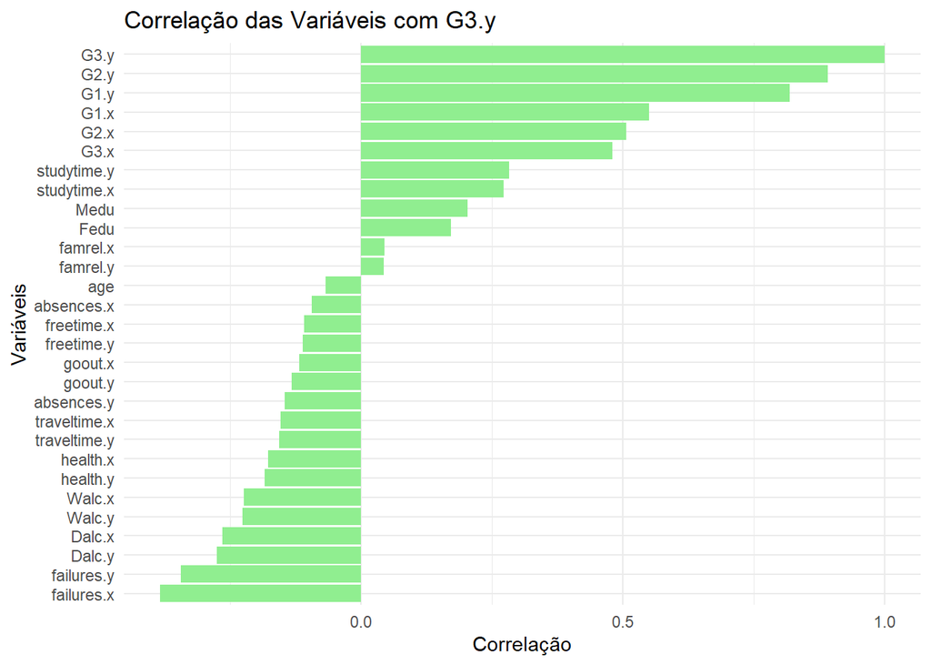

```r
# Visualizar as correlações em um gráfico
cor_g3_y_df <- as.data.frame(cor_g3_y_sorted)
cor_g3_y_df$Variable <- rownames(cor_g3_y_df)
colnames(cor_g3_y_df) <- c("Correlation", "Variable")

ggplot(cor_g3_y_df, aes(x = reorder(Variable, Correlation), y = Correlation)) +
  geom_bar(stat = "identity", fill = "lightgreen") +
  coord_flip() +
  labs(title = "Correlação das Variáveis com G3.y",
       x = "Variáveis",
       y = "Correlação") +
  theme_minimal()
```

### Questão 12

**Descrição:**  
Com a base de dados student_performance, consigo realizar diversas análises que ajudam a entender o desempenho acadêmico dos alunos. Por exemplo, posso fazer uma análise descritiva para explorar variáveis como notas finais (G1, G2, G3), idade, sexo e situação familiar. Além disso, é possível avaliar a correlação entre variáveis, identificando quais fatores impactam diretamente nas notas finais. Também posso utilizar técnicas de modelagem preditiva para prever o desempenho de alunos com base em outras variáveis, o que pode ser útil para intervenções.

Antes de realizar essas análises, é fundamental passar por um pré-processamento dos dados. Isso envolve tratar dados ausentes, codificar variáveis categóricas e normalizar as variáveis numéricas, se necessário. A identificação e o tratamento de outliers também são importantes, pois podem distorcer a análise. Essas etapas garantem que as análises e modelos gerados sejam mais precisos e confiáveis, permitindo que eu tire conclusões mais robustas sobre o desempenho acadêmico dos estudantes.

### Questão 13

**Descrição:**  
Ao analisar a base de dados student_performance, espera-se identificar padrões relacionados ao desempenho acadêmico dos alunos. Um dos conhecimentos mais comuns é que fatores como idade, sexo e situação socioeconômica podem influenciar as notas.. Além disso, é possível observar a relação entre a frequência a atividades extracurriculares e o desempenho escolar, já que o envolvimento em atividades sociais e culturais muitas vezes está associado a melhores resultados acadêmicos.

### Questão 14

**Descrição:**

[output not shown]

No primeiro estudo, a ênfase foi na utilização de redes neurais para entender melhor os padrões que influenciam a performance dos alunos, o que pode facilitar a adaptação de sistemas acadêmicos. No segundo, a discussão focou em como métodos de regressão penalizada podem aprimorar a análise estatística, reduzindo a variância e melhorando a precisão em dados de performance estudantil. Ambos os estudos indicam a importância de um pré-processamento adequado dos dados, como a normalização e a seleção de características relevantes, para garantir a eficácia dos modelos de análise.

Esses estudos não apenas reforçam a relevância de entender a performance estudantil, mas também mostram como técnicas avançadas de análise de dados podem ser aplicadas para extrair insights valiosos sobre os fatores que afetam o aprendizado

### Questão 15

Para futuras análises, seria interessante aprofundar o estudo em variáveis não apenas quantitativas, mas também qualitativas, como o ambiente familiar e a motivação dos alunos. A inclusão de dados mais variados e representativos poderia enriquecer ainda mais as conclusões. Além disso, a aplicação de técnicas de machine learning poderia aprimorar a previsão de desempenho acadêmico, oferecendo ferramentas valiosas para intervenções educativas.

Experiência com o Relatório: Durante a elaboração do relatório, enfrentei alguns desafios, como a limpeza e o pré-processamento dos dados, que exigiram atenção aos detalhes e um bom conhecimento de R. A parte que mais me chamou a atenção foi a análise de correlação, pois me permitiu visualizar relações que não eram evidentes à primeira vista. Minha experiência anterior com análise estatística e programação em R foi fundamental para superar as dificuldades e desenvolver um entendimento mais profundo do conjunto de dados.

A interação com meus colegas foi muito positiva, permitindo trocas de ideias e insights que enriqueceram o processo de análise. A colaboração facilitou a resolução de problemas e a aplicação de diferentes perspectivas na interpretação dos dados. Isso não só melhorou a qualidade do relatório final, mas também contribuiu para um aprendizado coletivo sobre análise de dados e estatísticas aplicadas.